# Relatório Final - Problema 1

# Intro

Os dados que estão sendo analisados são referentes aos gastos declarados pelos deputados durante o ano de 2016. Cada parlamentar tem uma cota que pode ser usada com as suas despesas necessárias para o exercício da profissão, todavia os gastos tem que ser declarados, além disso eles também são divididos em categorias específicas. A ideia desse relatório é fazer uma análise exploratória e descritiva desses gastos e apartir dessa análise extrair informações úteis dos dados.

# Escolha das perguntas guia

A primeira curiosidade que surgiu ao receber os dados foi tentar descobrir qual a categoria que os deputados gastam mais.

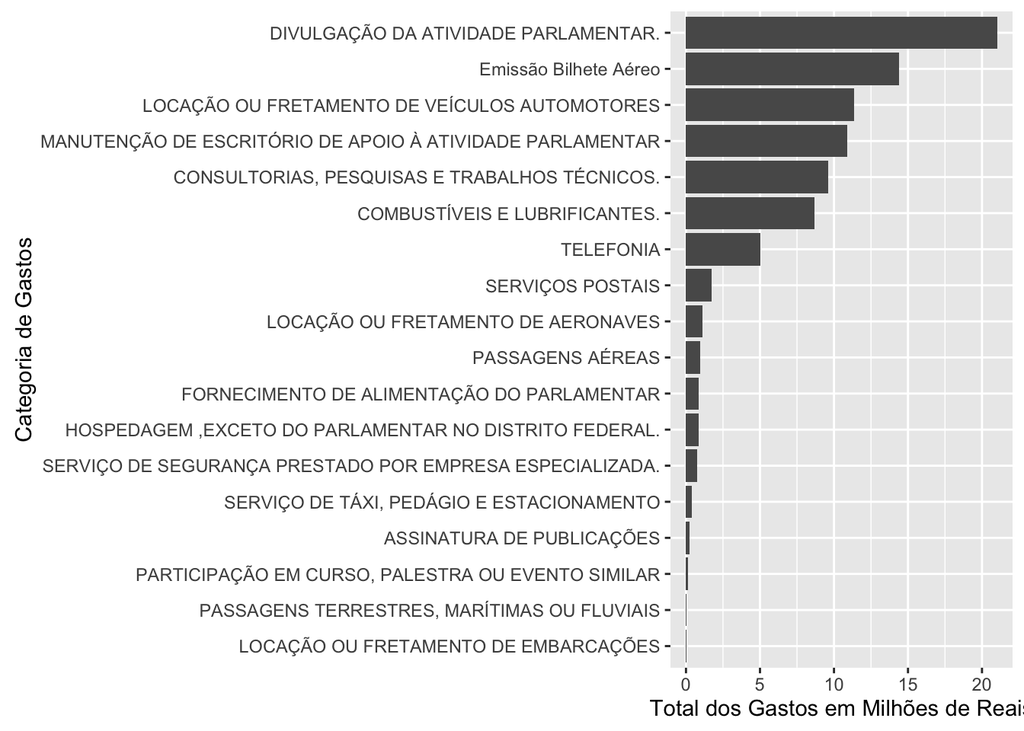

Ao ver esse gráfico fica bem claro que os dois maiores gastos são com Divulgação da Atividade Parlamentar e Emissão de Bilhete Aéreo.

Outra curiosidade que surgiu foi saber quais as empresas que mais recebem dinheiro dos deputados.

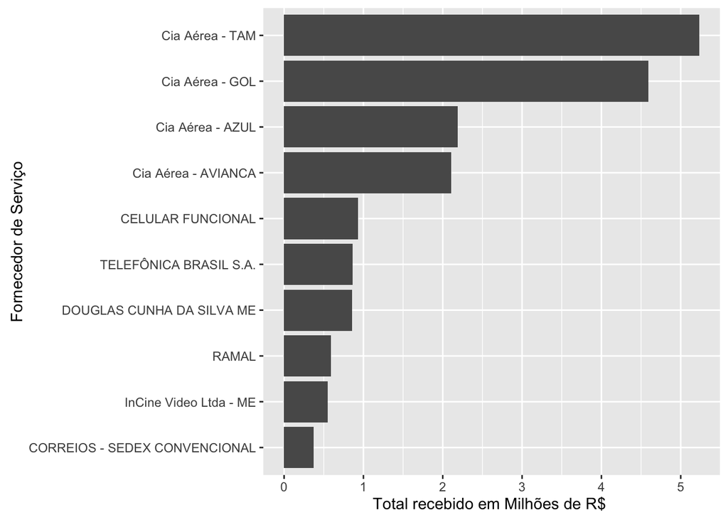

```r
fornecedores <- group_by(ano.atual,txtFornecedor)
fornecedores_sum <- summarise(fornecedores, total=sum(vlrLiquido))

fornecedores_Arranged <- arrange(fornecedores_sum,desc(total))

top10Fornecedores <- head(fornecedores_Arranged,10)

top10Fornecedores <- transform(top10Fornecedores,
                          txtFornecedor = reorder(txtFornecedor, total))

top10Fornecedores <- transform(top10Fornecedores, total = total/ 1000000)

p <- ggplot(top10Fornecedores, aes(x = txtFornecedor, y = total))
p + geom_bar(stat="identity", position = "dodge") + coord_flip() + labs(y = "Total recebido em Milhões de R$ ", x = "Fornecedor de Serviço")
```

Verificando o ranking dos fornecedores encontramos um resultado que já era esperado pois como observamos antes os maiores gastos são com transporte aéreo e nesse ranking os primeiros colocados são empresas de transporte aéreo. Todavia, vemos um micro empreendedor que recebeu uma quantidade de dinheiro considerável o Douglas Cunha da Silva. Decidi então investigar mais sobre os dados relacionados a esse investidor.

# 1 - Qual a variação dos dados do fornecedor Douglas Cunha Da Silva Me?

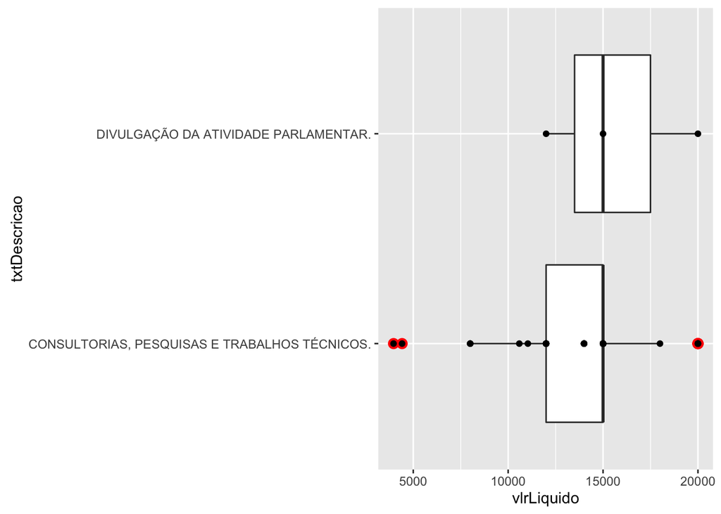

Ao analisar esse gráfico vemos que os gastos variam muito de preço e a maior parte do dinheiro é usado em Consultorias, Pesquisas e Trabalhos Técnicos.

Uma outra curiosidade que surge é descobrir quais os parlamentares que mais contrataram esse serviço. Analisando o Gráfico:

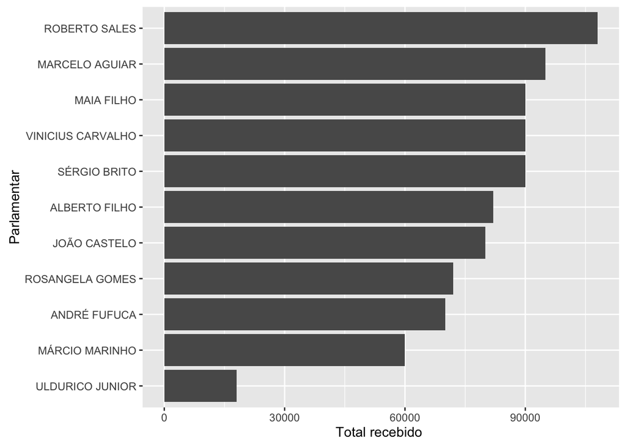

Vemos que o parlamentar que mais gastou com essa empresa foi o Roberto Sales, gastando mais de R$ 90000,00.

Sabendo quais os parlamentares que mais gastam agora eu desejo saber se esse fornecedor é uma preferência de dado partido, analisando agora os gastos por partido.

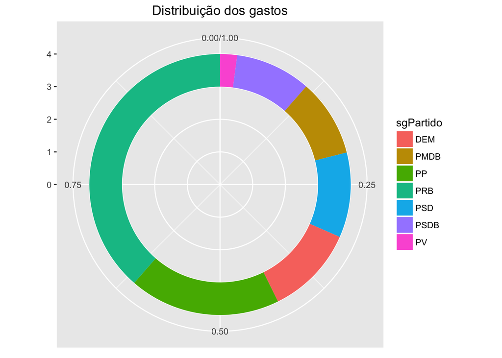

De acorodo com a distribuição vemos que o PRB é o que mais gasta com serviços prestados pela Douglas Cunha Da Silva Me. Bastante compreensível dado que o Roberto Sales é do PRB.

# 2 - Qual o número de pessoas para quem um deputado já pagou passagem? ##levaEuParlamentar

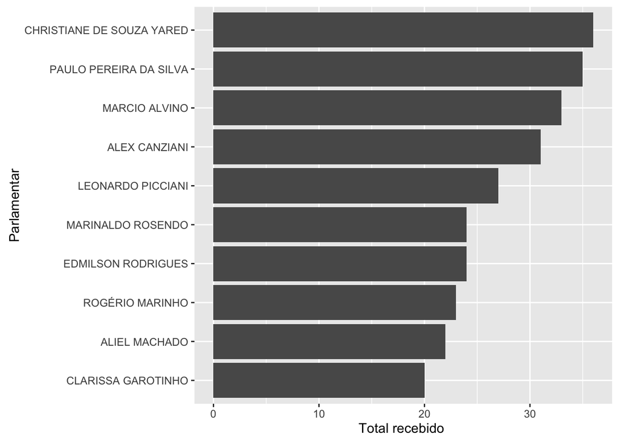

Podemos ver que a parlamentar que mais compra passagens para pessoas diferentes é a Christiane de Souza, que comprou passagens para 36 pessoas diferentes seguido por Paulo Pereira com 35.

Será que esses valores são considerados normais?

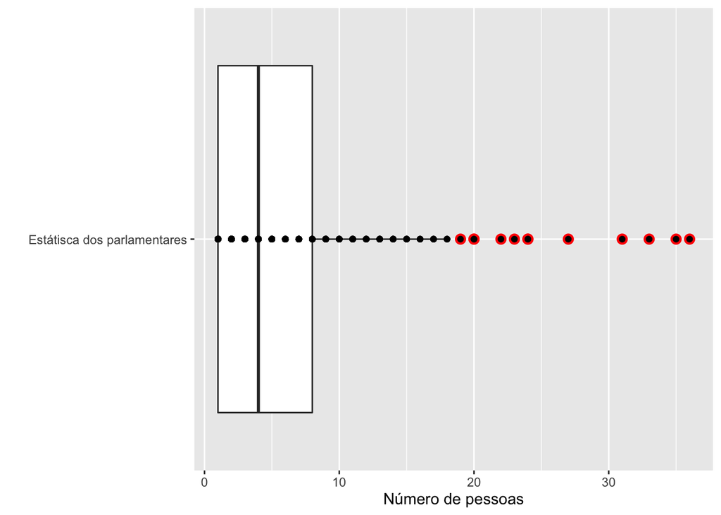

Os pontos em vermelhos são considerados atípicos, ou seja, todos os parlamentares que estavam na lista do top 10 pagaram passagens para um número alto de pessoas, maior do que o normal.